# A3: Incarceration

Thao-Nguyen Ho

8/6/2023

### Introduction

Incarceration is a big problem in the U.S. and negatively impacts communities, especially minorities. Understanding this issue can help design better policies to reduce incarceration rates across the country and break down the racial and gender disparities embedded in this issue. To explore patterns of incarceration in the U.S., I’ll be looking at this [dataset about jail population per county/state](https://github.com/melaniewalsh/Neat-Datasets/blob/main/us-jail-pop.csv?raw=true). Due to having a lot of missing values in the years before 1990, I’ll only focus on data that are recorded from 1990 to 2018, specifically for the population aged 15 to 64 as this group is the most likely to be incarcerated.

The measure of incarceration I’ll be focusing on is the incarceration percentage of a particular group population. One of the variables I’ll be analyzing is race because I’m interested in seeing how racial disparities have changed over time and which groups have higher or increasing rates of incarceration. Another variable I’ll be looking at is gender, specifically the relationship between males’ and females’ jail incarceration rate, to better understand how gender differences and biases can affect the incarceration rate. Lastly, I’ll be examining the incarceration of the most affected group across different states of the U.S. to discover any geographical clusters and factors that can contribute to the inequalities in the criminal justice system.

### The Dataset

Who collected the data?

- The data was collected by the [Vera Institute](https://github.com/vera-institute/incarceration-trends)

How was the data collected or generated?

- From the [Codebook](https://github.com/vera-institute/incarceration-trends/blob/master/incarceration_trends-Codebook.pdf), the data was collected from datasets provided by the U.S. Department of Justice Bureau of Justice Statistics (BJS), the Deaths in Custody Reporting Program (DCRP), and the Annual Survey of Jails.

Why was the data collected?

- The data was collected to document and inform the public of mass incarceration in the U.S. It can be used by others as a tool to understand who and how many are in jails/prisons and to analyze patterns that can reveal the disparities in the criminal justice system.

How many observations (rows) are in your data?

- There are 153811 observations (rows) in the dataset.

How many features (columns) are in the data?

- There are 28 features (columns) in the dataset.

What, if any, ethical questions or questions of power do you need to consider when working with this data?

- When working with this data, some ethical questions I need to consider are related to the privacy of the individuals. These questions include what kinds of information are collected from each individual and how this information is stored, and whether the participants are aware of this whole process. Because the values presented in this data are mostly numbers, how can we make sure that they are not over or under estimate for certain gender or racial groups, and whether there’re biases presented in the data.

What are possible limitations or problems with this data? (at least 200 words)

### Trends Over Time Chart

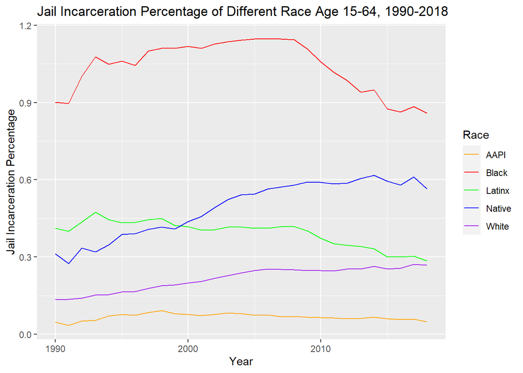

This chart visualizes the jail incarceration percentage of different racial groups from the age of 15 to 64 in the U.S. 1990-2018. A racial group’s percentage represents the percentage of people in jail in relation to that group’s total population.

#### Purpose

By comparing the jail incarceration percentage over time of different racial groups, this chart seeks to express the trends of the incarcerated population and which group has the highest incarceration rates. The chart allows us to see which year there was a sudden spike in the incarceration rate and allows for further analysis of the racial disparities in the criminal justice system. Understanding these patterns can provide insights into creating programs that help lower the incarceration rates of the most affected groups.

### Variable Comparison Chart

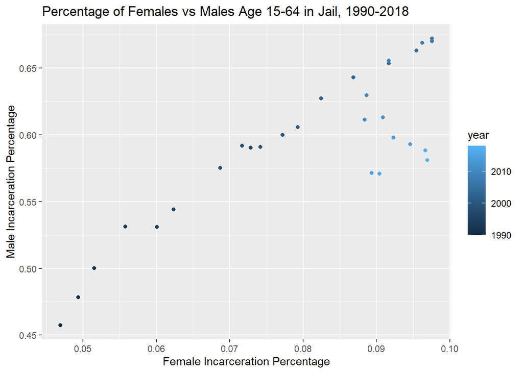

This chart visualizes the relationship between males’ and females’ jail incarceration percentages from the age of 15 to 64 in the U.S. 1990-2018. A gender’s percentage represents the percentage of people in jail in relation to that gender’s total population.

#### Purpose

By showing the correlation between males’ and females’ incarceration percentages, this chart seeks to show how these two variables are related to one another and the direction that they both are going over the years. It allows us to see which gender is increasing or decreasing at a faster rate and whether this affect the outcome of the other gender. Understanding these patterns can help make changes to policies that better fit the needs of both groups and explore gender biases in the criminal justice system.

### Map

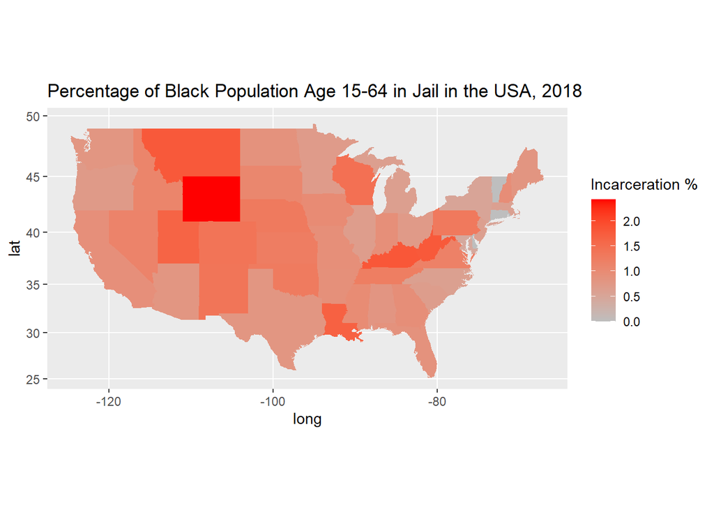

This chart visualizes the jail incarceration percentage of the Black population from the age of 15 to 64 in 2018 across different states of the U.S.

#### Purpose

By showing how the Black jail incarceration percentage varies geographically, this chart seeks to show which state has the highest percentage of its Black population incarcerated and which one has the lowest. It allows us to see whether there’re patterns across the different states, like geographical clusters of Black incarceration, and to question and explore why such patterns exist.

#### Patterns

- Some states like **Connecticut, Delaware, and Vermont** have **0%** of their Black population incarcerated, indicating that there are missing data for these states.
  - Alaska and Hawaii are missing from the map due to limited technical skills.
- **Wyoming** is the state with the **highest** Black jail incarceration percentage, in which **2.43%** of its Black population from the age of 15 to 64 are in jail in 2018.
  - The states around Wyoming also have a high percentage. More context about each state needs to be explored to understand why these states have high Black incarceration percentages.